# Stock price project

1. Data Preparation:
- I use the MSCI data set of 6 developed countries: US, UK, Japan, Germany, France and Canada at https://www.msci.com/end-of-day-data-country
- Data frequencies: monthly and annual.
- Date length: full sample (possibly from 1969).
- Currency domination: USD.
- Size: Standard.
1. I clean data by removing NA valuesa then calculate returns for each series in the data set. I then use matplotlib and seaborn package to produce plot of the above data set in two frequencies of monthly and annual levels as well as at both price and return levels and provide summary statistics of the data.
2. I perform Cointegration Test as follows:
- Using the Engle – Grangle 2 – step method to detect for any possible cointegration between the US and each of the other 5 countries.
- Using the Johansen technique to detect for any possible cointegration among the 6 countries.
- Note: for the cointergration checking I follow the full procedure from Checking order of integration for each series, VAR lag length selection, estimation of long-run equation using VAR and short-run VECM and report any necessary statistics and comments.

```python
# Import the packages needed
import pandas as pd
import numpy as np
import os
import matplotlib.pyplot as plt
from statsmodels.graphics.gofplots import qqplot
import scipy.stats as stats
from scipy.stats import kstest
from statsmodels.tsa.stattools import coint
from statsmodels.tsa.vector_ar.vecm import coint_johansen, VECM
from statsmodels.tsa.vector_ar.var_model import VAR
from statsmodels.tsa.stattools import adfuller
from statsmodels.stats.diagnostic import acorr_ljungbox
import seaborn as sns
```

```python
# Create new lists, dictionaries
# Define the path to the folder
folder_path = r"D:\Portfolio Project\monthly"
# List all the xls files in the folder
file_list = ["USA.xlsx", "UK.xlsx", "JAPAN.xlsx", "CANADA.xlsx", "FRANCE.xlsx", "GERMANY.xlsx"]
# Initialize empty lists to store the data
monthly_price = []
monthly_returns = []
yearly_price = []
yearly_returns = []
# Initialize an empty DataFrame to store the price data for all countries
all_monthly_price = pd.DataFrame()
all_monthly_return = pd.DataFrame()
all_yearly_price = pd.DataFrame()
all_yearly_return = pd.DataFrame()
```

```python
# Iterate over each file
for file_name in file_list:
 # Create the file path
 file_path = os.path.join(folder_path, file_name)
 # Read the file, skipping the first 7 rows and selecting the desired columns
 monthly = pd.read_excel(file_path, skiprows=6, usecols="A:B", nrows=641)
 # Remove rows with NaN values
 monthly = monthly.dropna()
 # Rename the columns to "Date" and "Price"
 monthly.columns = ["Date", "Price"]
 # Convert the "Price" column to numeric values
 monthly["Price"] = pd.to_numeric(monthly["Price"], errors="coerce")
 # Convert the "Date" column to datetime values
 monthly["Date"] = pd.to_datetime(monthly["Date"], errors="coerce")
 # Set the "Date" column as the index
 monthly.set_index("Date", inplace=True)
 # Replace non-numeric values with NaN
 monthly["Price"] = monthly["Price"].mask(pd.to_numeric(monthly["Price"], errors="coerce").isna())
 # Extract the country name from the file name
 country_name = file_name[:-5]
 # Concatenate the country's price column to the DataFrame
 all_monthly_price = pd.concat([all_monthly_price, monthly["Price"]], axis=1)
 all_monthly_price.rename(columns={"Price": country_name}, inplace=True)
 # Convert monthly data to yearly data
 yearly = monthly.resample('Y').mean()
 # Calculate returns
 monthly["Returns"] = monthly["Price"].pct_change()
 yearly["Returns"] = yearly["Price"].pct_change()
 all_monthly_return = pd.concat([all_monthly_return, monthly["Returns"]], axis=1)
 all_monthly_return.rename(columns={"Returns": country_name}, inplace=True)
 all_yearly_return = pd.concat([all_yearly_return, yearly["Returns"]], axis=1)
 all_yearly_return.rename(columns={"Returns": country_name}, inplace=True)
 # Summary statistics
 print("Summary statistics of " + str(file_name[:-5]) + " monthly price:" + "\n" + str(monthly['Price'].describe()) + "\n")
 print("Summary statistics of " + str(file_name[:-5]) + " monthly returns:" + "\n" + str(monthly['Returns'].describe()) + "\n")
 print("Summary statistics of " + str(file_name[:-5]) + " yearly price:" + "\n" + str(yearly['Price'].describe()) + "\n")
 print("Summary statistics of " + str(file_name[:-5]) + " yearly returns:" + "\n" + str(yearly['Returns'].describe()) + "\n")
 # Store the data in respective lists
 monthly_price.append(monthly["Price"])
 monthly_returns.append(monthly["Returns"])
 yearly_price.append(yearly["Price"])
 yearly_returns.append(yearly["Returns"])

# Remove rows with NaN values
all_monthly_return = all_monthly_return.dropna()
all_yearly_return = all_yearly_return.dropna()
```

```
Summary statistics of USA monthly price:
count     641.000000
mean      965.758000
std      1009.088161
min        64.919000
25%       142.081000
50%       637.351000
75%      1315.438000
max      4593.595000
Name: Price, dtype: float64

Summary statistics of USA monthly returns:
count    640.000000
mean       0.006759
std        0.044501
min       -0.214616
25%       -0.018976
50%        0.010185
75%        0.035592
max        0.173016
Name: Returns, dtype: float64

Summary statistics of USA yearly price:
count      55.000000
mean      986.617409
std      1055.660673
min        84.069167
25%       136.180667
50%       640.670333
75%      1311.198417
max      4156.882583
Name: Price, dtype: float64

Summary statistics of USA yearly returns:
count    54.000000
mean      0.079126
std       0.137467
min      -0.242774
25%      -0.008822
50%       0.086841
```

[output cut: 208 more lines]

```
50%       859.292917
75%      1676.339500
max      2415.915500
Name: Price, dtype: float64

Summary statistics of GERMANY yearly returns:
count    54.000000
mean      0.075886
std       0.204834
min      -0.290713
25%      -0.062706
50%       0.061226
75%       0.210547
max       0.847205
Name: Returns, dtype: float64
```

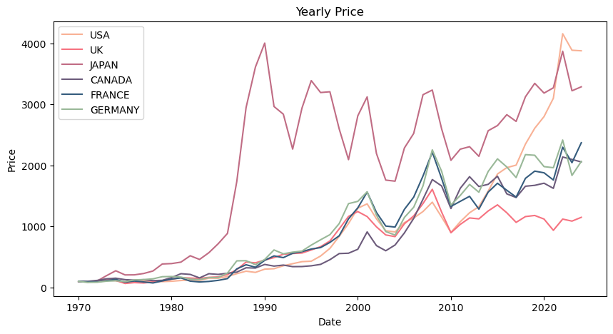

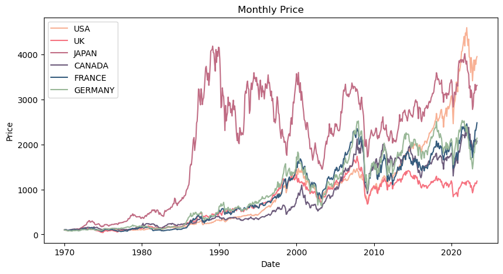

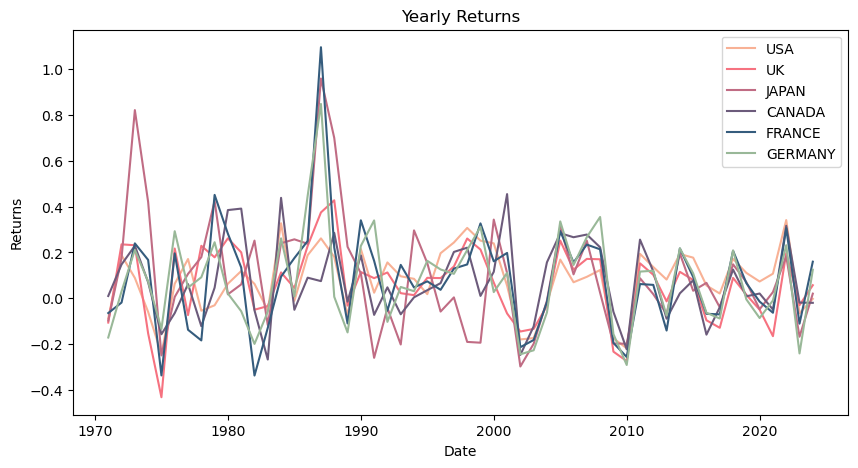

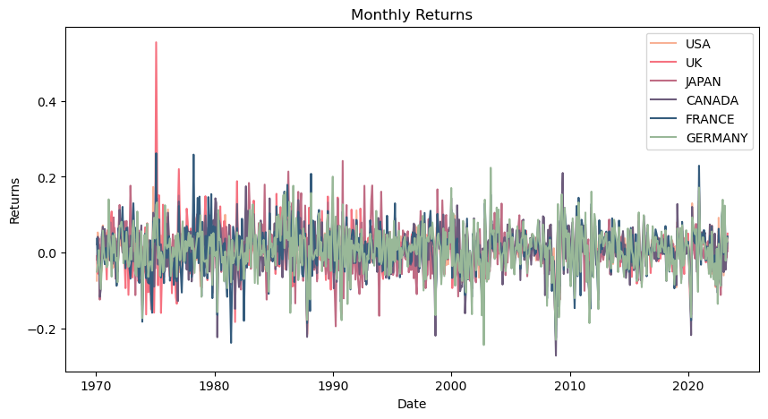

```python
# Produce plot
# Define a list of colors for each country
colors = ['#F8B195', '#F67280', '#C06C84', '#6C5B7B', '#355C7D', '#99B898']
# Plot yearly price of 6 countries
plt.figure(figsize=(10, 5))
for i, country_price in enumerate(yearly_price):
 plt.plot(country_price.index, country_price, label=file_list[i][:-5], color=colors[i])
plt.title("Yearly Price")
plt.xlabel("Date")
plt.ylabel("Price")
plt.legend()
plt.show()
# Plot monthly price of 6 countries
plt.figure(figsize=(10, 5))
for i, country_price in enumerate(monthly_price):
 plt.plot(country_price.index, country_price, label=file_list[i][:-5], color=colors[i])
plt.title("Monthly Price")
plt.xlabel("Date")
plt.ylabel("Price")
plt.legend()
plt.show()
# Plot yearly returns of 6 countries
plt.figure(figsize=(10, 5))
for i, country_returns in enumerate(yearly_returns):
 plt.plot(country_returns.index, country_returns, label=file_list[i][:-5], color=colors[i])
plt.title("Yearly Returns")
plt.xlabel("Date")
plt.ylabel("Returns")
plt.legend()
plt.show()
# Plot monthly returns of 6 countries
plt.figure(figsize=(10, 5))
for i, country_returns in enumerate(monthly_returns):
 plt.plot(country_returns.index, country_returns, label=file_list[i][:-5], color=colors[i])
plt.title("Monthly Returns")
plt.xlabel("Date")
plt.ylabel("Returns")
plt.legend()
plt.show()
```

```python
# Engle–Grangle 2–step method to detect cointegration between the US ang others
us_price = monthly_price[0]
other_price = monthly_price[1:]
for i, country_price in enumerate(other_price):
    # Perform cointegration test
    result = coint(us_price, country_price)
    print("Cointegration test result for {} and US:".format(file_list[i + 1][:-5]))
    print("===================================")
    print("Test statistic: ", result[0])
    print("P-value: ", result[1])
    print("Critical values: ", result[2])
    if result[1] < 0.05:
        print("Cointegration detected between {} and US.".format(file_list[i + 1][:-5]) + "\n")
    else:
        print("No cointegration detected between {} and US.".format(file_list[i + 1][:-5]) + "\n")
```

```
Cointegration test result for UK and US:
===================================
Test statistic:  0.2540764173258258
P-value:  0.9903408441697806
Critical values:  [-3.9136342  -3.34569369 -3.05108352]
No cointegration detected between UK and US.

Cointegration test result for JAPAN and US:
===================================
Test statistic:  -0.007476792355974472
P-value:  0.9857250611226029
Critical values:  [-3.9136342  -3.34569369 -3.05108352]
No cointegration detected between JAPAN and US.

Cointegration test result for CANADA and US:
===================================
Test statistic:  -0.21459983950082545
P-value:  0.9794558004650876
Critical values:  [-3.9136342  -3.34569369 -3.05108352]
No cointegration detected between CANADA and US.

Cointegration test result for FRANCE and US:
===================================
Test statistic:  -1.1054160279124465
P-value:  0.8809618563371822
Critical values:  [-3.9136342  -3.34569369 -3.05108352]
No cointegration detected between FRANCE and US.

Cointegration test result for GERMANY and US:
===================================
Test statistic:  -0.5240956667448601
P-value:  0.9625712755047948
Critical values:  [-3.9136342  -3.34569369 -3.05108352]
No cointegration detected between GERMANY and US.
```

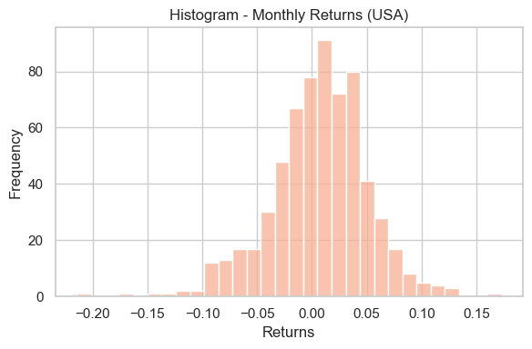

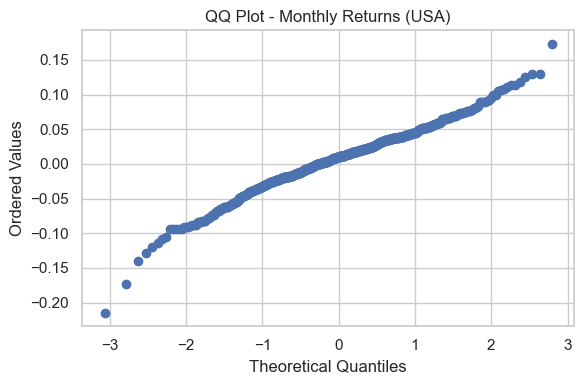

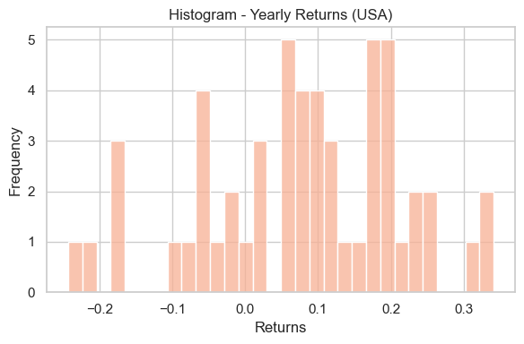

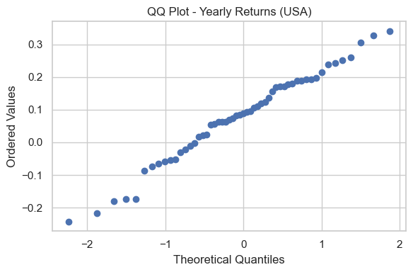

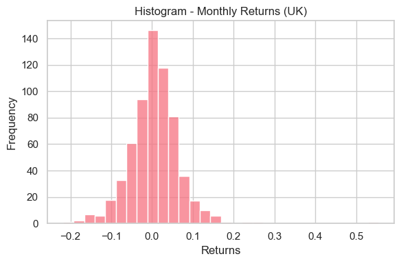

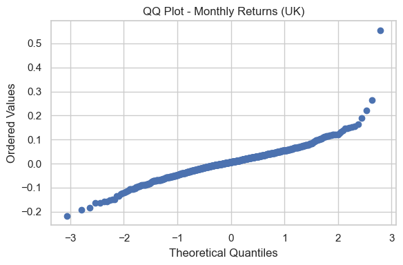

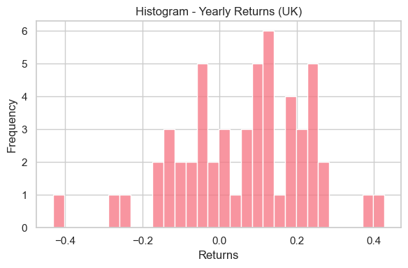

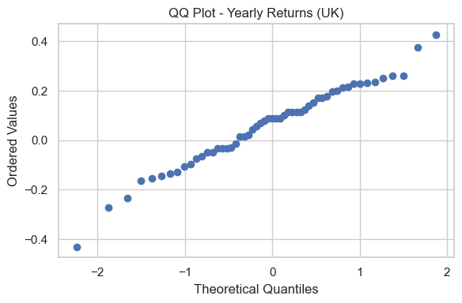

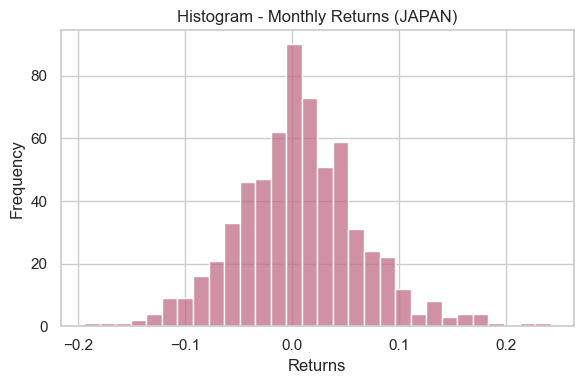

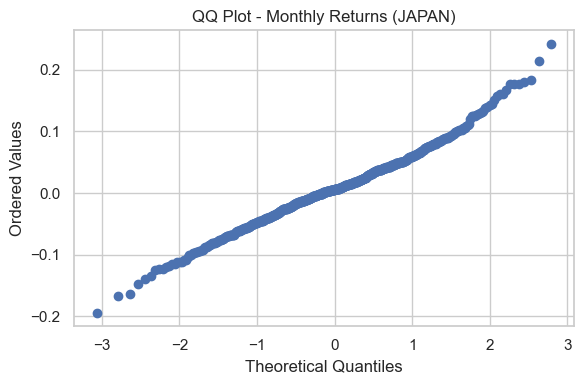

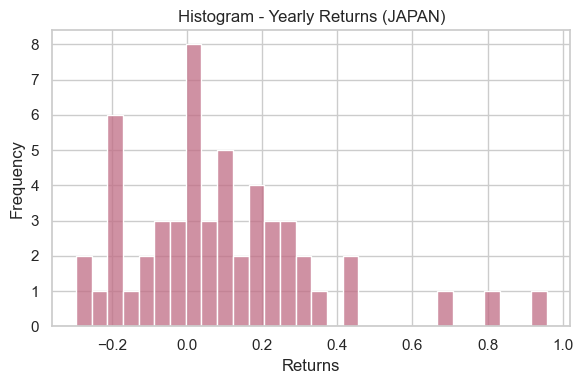

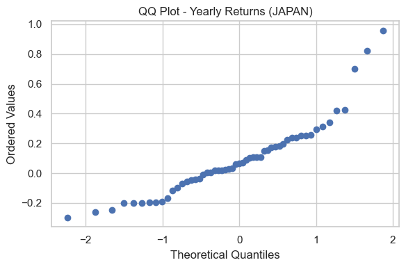

[12 more figures not shown]

```python
# Produce Q-Q plot and Histogram
# Set the Seaborn theme
sns.set_theme(style="whitegrid")
# Loop over each country
for i, file_name in enumerate(file_list):
    # Extract the country name from the file name
    country_name = file_name[:-5]
    # Adjusted code for histogram
    plt.figure(figsize=(6, 4))
    sns.histplot(monthly_returns[i], bins=30, color=colors[i % len(colors)])
    plt.title(f"Histogram - Monthly Returns ({country_name})")
    plt.xlabel("Returns")
    plt.ylabel("Frequency")
    plt.tight_layout()
    plt.show()
    # Adjusted code for QQ plot
    plt.figure(figsize=(6, 4))
    stats.probplot(monthly_returns[i], dist="norm", plot=plt)
    plt.title(f"QQ Plot - Monthly Returns ({country_name})")
    plt.xlabel("Theoretical Quantiles")
    plt.ylabel("Ordered Values")
    plt.tight_layout()
    plt.show()
    # Adjusted code for histogram
    plt.figure(figsize=(6, 4))
    sns.histplot(yearly_returns[i], bins=30, color=colors[i % len(colors)])
    plt.title(f"Histogram - Yearly Returns ({country_name})")
    plt.xlabel("Returns")
    plt.ylabel("Frequency")
    plt.tight_layout()
    plt.show()
    # Adjusted code for QQ plot
    plt.figure(figsize=(6, 4))
    stats.probplot(yearly_returns[i], dist="norm", plot=plt)
    plt.title(f"QQ Plot - Yearly Returns ({country_name})")
    plt.xlabel("Theoretical Quantiles")
    plt.ylabel("Ordered Values")
    plt.tight_layout()
    plt.show()
```

```python
# Kolmogorov-Smirnov test
for file_name in file_list:
     country_name = file_name[:-5]
     # Perform Kolmogorov-Smirnov test on monthly returns
     ks_statistic, ks_pvalue = stats.kstest(all_monthly_return[country_name], 'norm')
     print(f"Kolmogorov-Smirnov Test - Monthly Returns ({country_name}):")
     print(f"KS Statistic: " + str(ks_statistic))
     print(f"P-value: " + str(ks_pvalue))
     print(ks_pvalue < 0.01)
     print("")
     # Perform Kolmogorov-Smirnov test on yearly returns
     ks_statistic, ks_pvalue = stats.kstest(all_yearly_return[country_name], 'norm')
     print(f"Kolmogorov-Smirnov Test - Monthly Returns ({country_name}):")
     print(f"KS Statistic: " + str(ks_statistic))
     print(f"P-value: " + str(ks_pvalue))
     print(ks_pvalue < 0.01)
     print("")
```

```
Kolmogorov-Smirnov Test - Monthly Returns (USA):
KS Statistic: 0.44995041515945305
P-value: 9.104820283519008e-119
True

Kolmogorov-Smirnov Test - Monthly Returns (USA):
KS Statistic: 0.404090389351282
P-value: 1.7734304581135914e-08
True

Kolmogorov-Smirnov Test - Monthly Returns (UK):
KS Statistic: 0.43122714579684623
P-value: 1.1903928610061307e-108
True

Kolmogorov-Smirnov Test - Monthly Returns (UK):
KS Statistic: 0.37889376839768163
P-value: 1.7786900811253692e-07
True

Kolmogorov-Smirnov Test - Monthly Returns (JAPAN):
KS Statistic: 0.44120610745838956
P-value: 5.6149579083758116e-114
True

Kolmogorov-Smirnov Test - Monthly Returns (JAPAN):
KS Statistic: 0.3831332227975952
P-value: 1.2213164257999625e-07
True

Kolmogorov-Smirnov Test - Monthly Returns (CANADA):
KS Statistic: 0.4380851015890517
P-value: 2.698684668202746e-112
True

Kolmogorov-Smirnov Test - Monthly Returns (CANADA):
KS Statistic: 0.39474869114361366
P-value: 4.2535733520014856e-08
True

Kolmogorov-Smirnov Test - Monthly Returns (FRANCE):
KS Statistic: 0.4294193966965042
P-value: 1.0587319011205765e-107
True

Kolmogorov-Smirnov Test - Monthly Returns (FRANCE):
KS Statistic: 0.3681636977031772
P-value: 4.509043013194666e-07
True

Kolmogorov-Smirnov Test - Monthly Returns (GERMANY):
KS Statistic: 0.42845203368664164
P-value: 3.393814079483653e-107
True

Kolmogorov-Smirnov Test - Monthly Returns (GERMANY):
KS Statistic: 0.3856353957141852
P-value: 9.760765444055424e-08
True
```

```python
# Ljung-box Test
for file_name in file_list:
     country_name = file_name[:-5]
     # Perform Ljung-box Test for monthly return:
     ljung = acorr_ljungbox(all_monthly_return[country_name], lags=[2], return_df=True)
     print("Ljung-box Test for monthly return of " + str(country_name))
     print(ljung)
     print('')
     # Perform Ljung-box Test for yearly return:
     ljung = acorr_ljungbox(all_yearly_return[country_name], lags=[2], return_df=True)
     print("Ljung-box Test for yearly return of " + str(country_name))
     print(ljung)
     print('')
```

```
Ljung-box Test for monthly return of USA
    lb_stat  lb_pvalue
2  1.109627   0.574179

Ljung-box Test for yearly return of USA
    lb_stat  lb_pvalue
2  2.334206   0.311267

Ljung-box Test for monthly return of UK
   lb_stat  lb_pvalue
2  7.39013   0.024846

Ljung-box Test for yearly return of UK
    lb_stat  lb_pvalue
2  3.392197   0.183398

Ljung-box Test for monthly return of JAPAN
    lb_stat  lb_pvalue
2  6.422264   0.040311

Ljung-box Test for yearly return of JAPAN
    lb_stat  lb_pvalue
2  7.241001   0.026769

Ljung-box Test for monthly return of CANADA
    lb_stat  lb_pvalue
2  0.983312   0.611613

Ljung-box Test for yearly return of CANADA
    lb_stat  lb_pvalue
2  4.207302    0.12201

Ljung-box Test for monthly return of FRANCE
    lb_stat  lb_pvalue
2  2.508291    0.28532

Ljung-box Test for yearly return of FRANCE
    lb_stat  lb_pvalue
2  2.491997   0.287654

Ljung-box Test for monthly return of GERMANY
   lb_stat  lb_pvalue
2  0.81556   0.665125

Ljung-box Test for yearly return of GERMANY
    lb_stat  lb_pvalue
2  4.400847   0.110756
```

```python
# STATIONARY TEST
for file_name in file_list:
     country_name = file_name[:-5]
     # Perform stationery test for monthly return
     station = adfuller(all_monthly_return[country_name], autolag='AIC')
     print('ADF Test for monthly return of ' + country_name)
     print('ADF Statistic: %f' % station[0])
     print('p-value: %f' % station[1])
     if station[1] > 0.05:
         print("NON-STATIONARY for monthly return of " + country_name)
     # Perform stationery test for yearly return
     station = adfuller(all_yearly_return[country_name], autolag='AIC')
     print('ADF Test for yearly return of ' + country_name)
     print('ADF Statistic: %f' % station[0])
     print('p-value: %f' % station[1])
     if station[1] > 0.05:
         print("NON-STATIONARY for yearly return of " + country_name)
     print("")
```

```
ADF Test for monthly return of USA
ADF Statistic: -25.148602
p-value: 0.000000
ADF Test for yearly return of USA
ADF Statistic: -2.656517
p-value: 0.081870
NON-STATIONARY for yearly return of USA

ADF Test for monthly return of UK
ADF Statistic: -11.757839
p-value: 0.000000
ADF Test for yearly return of UK
ADF Statistic: -1.970329
p-value: 0.299732
NON-STATIONARY for yearly return of UK

ADF Test for monthly return of JAPAN
ADF Statistic: -12.713306
p-value: 0.000000
ADF Test for yearly return of JAPAN
ADF Statistic: -4.967539
p-value: 0.000026

ADF Test for monthly return of CANADA
ADF Statistic: -24.338123
p-value: 0.000000
ADF Test for yearly return of CANADA
ADF Statistic: -6.552282
p-value: 0.000000

ADF Test for monthly return of FRANCE
ADF Statistic: -13.086004
p-value: 0.000000
ADF Test for yearly return of FRANCE
ADF Statistic: -1.302730
p-value: 0.627922
NON-STATIONARY for yearly return of FRANCE

ADF Test for monthly return of GERMANY
ADF Statistic: -24.624017
p-value: 0.000000
ADF Test for yearly return of GERMANY
ADF Statistic: -4.966441
p-value: 0.000026
```

```python
# MORE ADF TEST
all_yearly_return1 = all_yearly_return.copy()
def adf(country_name):
     station = adfuller(all_yearly_return1[country_name], autolag='AIC')
     print('ADF Test for yearly return of ' + country_name)
     print('ADF Statistic: %f' % station[0])
     print('p-value: %f' % station[1])
     if station[1] > 0.05:
         print("NON-STATIONARY for yearly return of " + country_name)
     print("")
# differences
all_yearly_return1["USA - 2rd"] = all_yearly_return1["USA"].pct_change()
all_yearly_return1["USA - 2rd"] = all_yearly_return1["USA - 2rd"].replace([np.nan, -np.inf], 0)
all_yearly_return1["UK - 2rd"] = all_yearly_return1["UK"].pct_change()
all_yearly_return1["UK - 2rd"] = all_yearly_return1["UK - 2rd"].replace([np.nan, -np.inf], 0)
all_yearly_return1["FRANCE - 2rd"] = all_yearly_return1["FRANCE"].pct_change()
all_yearly_return1["FRANCE - 2rd"] = all_yearly_return1["FRANCE - 2rd"].replace([np.nan, -np.inf], 0)
adf("USA - 2rd")
adf("UK - 2rd")
adf("FRANCE - 2rd")
```

```
ADF Test for yearly return of USA - 2rd
ADF Statistic: -7.163556
p-value: 0.000000

ADF Test for yearly return of UK - 2rd
ADF Statistic: -7.452747
p-value: 0.000000

ADF Test for yearly return of FRANCE - 2rd
ADF Statistic: -7.761968
p-value: 0.000000
```

```python
import warnings
# Suppress the warning
warnings.filterwarnings("ignore")
# VAR LENGTH SELECTION
# for monthly return
model = VAR(all_monthly_return)
sorted_order = model.select_order(maxlags=10)
print(sorted_order.summary())
# for yearly return
model = VAR(all_yearly_return)
sorted_order = model.select_order(maxlags=6)
print(sorted_order.summary())
no_lag = 6
```

```
 VAR Order Selection (* highlights the minimums)
==================================================
       AIC         BIC         FPE         HQIC
--------------------------------------------------
0      -37.61*     -37.57*  4.631e-17*     -37.59*
1       -37.58      -37.29   4.770e-17      -37.47
2       -37.53      -36.98   5.008e-17      -37.32
3       -37.51      -36.71   5.127e-17      -37.20
4       -37.47      -36.41   5.316e-17      -37.06
5       -37.47      -36.15   5.359e-17      -36.96
6       -37.44      -35.87   5.492e-17      -36.83
7       -37.39      -35.57   5.800e-17      -36.68
8       -37.36      -35.29   5.959e-17      -36.56
9       -37.36      -35.03   5.961e-17      -36.46
10      -37.31      -34.73   6.257e-17      -36.31
--------------------------------------------------
 VAR Order Selection (* highlights the minimums)
=================================================
      AIC         BIC         FPE         HQIC
-------------------------------------------------
0      -24.09     -23.85*   3.458e-11      -24.00
1      -23.86      -22.22   4.395e-11      -23.24
2      -23.13      -20.08   9.841e-11      -21.98
3      -22.97      -18.53   1.389e-10      -21.29
4      -23.39      -17.54   1.376e-10      -21.18
5      -24.39      -17.14   1.104e-10      -21.65
6     -28.82*      -20.17  6.203e-12*     -25.55*
-------------------------------------------------
```

```python
# Perform cointegration test using Engle-Granger for each pair of countries (yearly data)
print("COINTEGRATION TEST OF EACH PAIR OF COUNTRY")
for i in range(len(file_list)):
     for j in range(i + 1, len(file_list)):
         country1 = file_list[i][:-5]
         country2 = file_list[j][:-5]
         # Perform cointegration test
         result = coint(all_yearly_return[country1], all_yearly_return[country2])
         print(f"Cointegration Test - {country1} and {country2}")
         print(f"Test Statistic: {result[0]}")
         print(f"P-value: {result[1]}")
         print(f"Critical Values:")
         for key, value in zip(['1%', '5%', '10%'], result[2]):
             print(f" {key}: {value}")
         # Check if there is cointegration
         if result[1] < 0.05:
             print(f"There is evidence of cointegration between {country1} and {country2}")
         else:
             print(f"There is no evidence of cointegration between {country1} and {country2}")
         print("")
```

```
COINTEGRATION TEST OF EACH PAIR OF COUNTRY
Cointegration Test - USA and UK
Test Statistic: -5.827459976998634
P-value: 3.789590248153612e-06
Critical Values:
 1%: -4.115015186899252
 5%: -3.453843883944464
 10%: -3.1254409576361692
There is evidence of cointegration between USA and UK

Cointegration Test - USA and JAPAN
Test Statistic: -2.646065210553828
P-value: 0.21957333742671942
Critical Values:
 1%: -4.115015186899252
 5%: -3.453843883944464
 10%: -3.1254409576361692
There is no evidence of cointegration between USA and JAPAN

Cointegration Test - USA and CANADA
Test Statistic: -4.597778191513971
P-value: 0.0008421059058246785
Critical Values:
 1%: -4.115015186899252
 5%: -3.453843883944464
 10%: -3.1254409576361692
There is evidence of cointegration between USA and CANADA

Cointegration Test - USA and FRANCE
Test Statistic: -3.188826600337687
P-value: 0.07181632324388167
Critical Values:
 1%: -4.115015186899252
 5%: -3.453843883944464
 10%: -3.1254409576361692
There is no evidence of cointegration between USA and FRANCE

Cointegration Test - USA and GERMANY
Test Statistic: -3.4956179185656464
P-value: 0.032785832227803055
```

[output cut: 80 more lines]

```
P-value: 0.05087080664888427
Critical Values:
 1%: -4.115015186899252
 5%: -3.453843883944464
 10%: -3.1254409576361692
There is no evidence of cointegration between CANADA and GERMANY

Cointegration Test - FRANCE and GERMANY
Test Statistic: -6.454368078188094
P-value: 1.5985527379242366e-07
Critical Values:
 1%: -4.115015186899252
 5%: -3.453843883944464
 10%: -3.1254409576361692
There is evidence of cointegration between FRANCE and GERMANY
```

```python
# Johansen test
print("JOHANSEN TEST")
# Perform Johansen's Test of Cointegration for each pair of countries (yearly data)
for i in range(len(file_list)):
     for j in range(i + 1, len(file_list)):
         country1 = file_list[i][:-5]
         country2 = file_list[j][:-5]
         # Select the yearly returns for the pair of countries
         pair_yearly_returns = all_yearly_return[[country1, country2]]
         # Perform Johansen's test
         result = coint_johansen(pair_yearly_returns, det_order=0, k_ar_diff=1)
         print(f"Johansen's Test - {country1} and {country2}")
         print(f"Eigenvalues:")
         for eigenvalue in result.eig:
             print(f" {eigenvalue}")
         print(f"Trace Statistic:")
         for trace_stat in result.lr1:
             print(f" {trace_stat}")
         print(f"Critical Values (90% Confidence Level):")
         for key, value in zip(['0%', '5%', '10%'], result.cvt[:, 0]):
             print(f" {key}: {value}")
         # Check if there is cointegration
         rank = result.evec.shape[1]
         if rank > 0:
             print(f"Cointegration Rank: {rank}")
             print(f"There is evidence of cointegration between {country1} and {country2}")
         else:
             print(f"Cointegration Rank: 0")
             print(f"There is no evidence of cointegration between {country1} and {country2}")
         print("")
```

```
JOHANSEN TEST
Johansen's Test - USA and UK
Eigenvalues:
 0.36691218573585827
 0.20637571776042057
Trace Statistic:
 35.79114579266641
 12.019546546771675
Critical Values (90% Confidence Level):
 0%: 13.4294
 5%: 2.7055
Cointegration Rank: 2
There is evidence of cointegration between USA and UK

Johansen's Test - USA and JAPAN
Eigenvalues:
 0.3681593346095131
 0.24431539155494486
Trace Statistic:
 38.440958545053576
 14.566821071129393
Critical Values (90% Confidence Level):
 0%: 13.4294
 5%: 2.7055
Cointegration Rank: 2
There is evidence of cointegration between USA and JAPAN

Johansen's Test - USA and CANADA
Eigenvalues:
 0.4653073560368725
 0.23375836620600024
Trace Statistic:
 46.40068703950829
 13.845400928727216
Critical Values (90% Confidence Level):
 0%: 13.4294
 5%: 2.7055
Cointegration Rank: 2
There is evidence of cointegration between USA and CANADA

```

[output cut: 140 more lines]

```
Cointegration Rank: 2
There is evidence of cointegration between CANADA and GERMANY

Johansen's Test - FRANCE and GERMANY
Eigenvalues:
 0.4243096173522978
 0.2996551395793464
Trace Statistic:
 47.23512042307746
 18.52148519056808
Critical Values (90% Confidence Level):
 0%: 13.4294
 5%: 2.7055
Cointegration Rank: 2
There is evidence of cointegration between FRANCE and GERMANY
```

```python
# Extract the results of the cointegration test
trace_stat = result.lr1 # Trace statistic
trace_crit_vals = result.cvt # Critical values for trace statistic
eig_stat = result.lr2 # Eigenvalue statistic
eig_crit_vals = result.cvm # Critical values for eigenvalue statistic
print("Trace Statistic:")
print(trace_stat)
print("\nCritical Values for Trace Statistic:")
print(trace_crit_vals)
print("\nEigenvalue Statistic:")
print(eig_stat)
print("\nCritical Values for Eigenvalue Statistic:")
print(eig_crit_vals)
```

```
Trace Statistic:
[47.23512042 18.52148519]

Critical Values for Trace Statistic:
[[13.4294 15.4943 19.9349]
 [ 2.7055  3.8415  6.6349]]

Eigenvalue Statistic:
[28.71363523 18.52148519]

Critical Values for Eigenvalue Statistic:
[[12.2971 14.2639 18.52  ]
 [ 2.7055  3.8415  6.6349]]
```

```python
# Check RATE
rate = 0
for i in range(0, rank):
     if trace_stat[i] > trace_crit_vals[i][2] and eig_stat[i] > eig_crit_vals[i][2]:
         rate = rate + 1
     else:
         rate = rate
print("Rate = " + str(rate))
```

```
Rate = 2
```

```python
# If rate > 0 and rate < number of variables, Apply VECM
if rate < len(file_list) and rate > 0:
    # Cointegration exists case
    print("Cointegration exists among the variables.")
    print("The variables are non-stationary, and the number of cointegrating relationships is equal to", rate)
    print("Apply VECM to analyze short-run coefficients and long-run equilibrium/cointegration relationship.")

    # Perform VECM
    model_vecm = VECM(all_yearly_return, k_ar_diff=6, coint_rank=2, deterministic="co")
    results_vecm = model_vecm.fit()

    print("VECM Results - Short-run coefficients and Long-run equilibrium relationship:")
    print(results_vecm.summary())

    # Form equation for VECM
    coef_shortrun = results_vecm.gamma
    coef_longrun = results_vecm.beta
    coef_loading = results_vecm.alpha
    variables = results_vecm.names
    eq1 = {}

    for i in range(0, 6):
        equation1 = ""
        y = coef_shortrun[i]
        reshaped_y = np.reshape(y, (6, -1))
        equation1 += "Δ^" + variables[i] + " = "
        equation1 += str(results_vecm.const[i][0]) + " + "

        for j in range(0, 6):
            L = "Δ" + ".L" + str(j + 1) + "."

            for k in range(0, 6):
                var = variables[k]
                coef = reshaped_y[j][k]
                equation1 += str(coef) + str(L) + str(var) + " + "

        equation1 = equation1[:-3]
        eq1[file_list[i]] = equation1

    for i in range(0, 6):
        equation2 = ""
        ec1 = coef_loading[i][0]
        equation2 += str(ec1) + " * " + "("

        for j in range(0, 6):
            var = variables[j]
            if j != i:
                beta_ec1 = coef_longrun[j][0]
                equation2 += str(beta_ec1) + "." + str(var) + " + "

        equation2 = equation2[:-3]
        equation2 += ")"
        eq1[file_list[i]] += " + " + equation2

    for i in range(0, 6):
        equation3 = ""
        ec1 = coef_loading[i][1]
        equation3 += str(ec1) + " * " + "("

        for j in range(0, 6):
            var = variables[j]
            if j != i:
                beta_ec1 = coef_longrun[j][0]
                equation3 += str(beta_ec1) + "." + str(var) + " + "

        equation3 = equation3[:-3]
        equation3 += ")" + "\n"
        eq1[file_list[i]] += " + " + equation3
        print(eq1[file_list[i]])
```

```
Cointegration exists among the variables.
The variables are non-stationary, and the number of cointegrating relationships is equal to 2
Apply VECM to analyze short-run coefficients and long-run equilibrium/cointegration relationship.
VECM Results - Short-run coefficients and Long-run equilibrium relationship:
Det. terms outside the coint. relation & lagged endog. parameters for equation USA
==============================================================================
                 coef    std err          z      P>|z|      [0.025      0.975]
------------------------------------------------------------------------------
const          0.0568      0.025      2.243      0.025       0.007       0.106
L1.USA         0.9038      0.187      4.839      0.000       0.538       1.270
L1.UK         -0.9449      0.142     -6.663      0.000      -1.223      -0.667
L1.JAPAN       0.3888      0.178      2.188      0.029       0.041       0.737
L1.CANADA      0.9676      0.451      2.144      0.032       0.083       1.852
L1.FRANCE     -1.1027      0.175     -6.302      0.000      -1.446      -0.760
L1.GERMANY    -0.3527      0.434     -0.813      0.416      -1.203       0.498
L2.USA         0.5718      0.360      1.589      0.112      -0.133       1.277
L2.UK         -0.9636      0.191     -5.056      0.000      -1.337      -0.590
L2.JAPAN       1.1273      0.151      7.458      0.000       0.831       1.424
L2.CANADA      0.7150      0.326      2.194      0.028       0.076       1.354
L2.FRANCE     -1.1228      0.255     -4.405      0.000      -1.622      -0.623
L2.GERMANY    -0.3531      0.547     -0.646      0.518      -1.425       0.719
L3.USA         1.5341      0.503      3.049      0.002       0.548       2.520
L3.UK         -1.0532      0.266     -3.963      0.000      -1.574      -0.532
L3.JAPAN       1.0997      0.190      5.800      0.000       0.728       1.471
L3.CANADA      0.5151      0.311      1.654      0.098      -0.095       1.125
L3.FRANCE     -1.5063      0.223     -6.745      0.000      -1.944      -1.069
L3.GERMANY    -0.3543      0.506     -0.700      0.484      -1.347       0.638
L4.USA         0.4964      0.249      1.993      0.046       0.008       0.985
L4.UK         -0.2532      0.282     -0.897      0.370      -0.806       0.300
L4.JAPAN       1.2011      0.193      6.221      0.000       0.823       1.580
L4.CANADA      0.9873      0.304      3.244      0.001       0.391       1.584
L4.FRANCE     -2.6863      0.218    -12.318      0.000      -3.114      -2.259
L4.GERMANY     0.5932      0.266      2.230      0.026       0.072       1.115
L5.USA        -0.2128      0.157     -1.356      0.175      -0.521       0.095
L5.UK         -0.3747      0.166     -2.255      0.024      -0.700      -0.049
L5.JAPAN       0.8163      0.150      5.456      0.000       0.523       1.110
L5.CANADA      0.3929      0.262      1.502      0.133      -0.120       0.905
L5.FRANCE     -2.1475      0.226     -9.507      0.000      -2.590      -1.705
L5.GERMANY     1.0996      0.209      5.263      0.000       0.690       1.509
L6.USA        -0.6352      0.216     -2.943      0.003      -1.058      -0.212
```

[output cut: 263 more lines]

```
beta.4        -0.8414    5.3e-09  -1.59e+08      0.000      -0.841      -0.841
beta.5         1.6576        nan        nan        nan         nan         nan
beta.6        -2.1499   7.98e-09  -2.69e+08      0.000      -2.150      -2.150
==============================================================================
Δ^USA = 0.05679875520508426 + 0.9038185534832494Δ.L1.USA + -0.9448874261836964Δ.L1.UK + 0.388843943586665Δ.L1.JAPAN + 0.9676127008996482Δ.L1.CANADA + -1.1027234968446906Δ.L1.FRANCE + -0.35265816922767884Δ.L1.GERMANY + 0.5717533024587154Δ.L2.USA + -0.9636391872354841Δ.L2.UK + 1.1273016835045973Δ.L2.J…

Δ^UK = -0.11665975205576734 + 0.11399548129884862Δ.L1.USA + -1.0763508711737801Δ.L1.UK + -0.5387964978696034Δ.L1.JAPAN + -1.7548297400260005Δ.L1.CANADA + -0.8066533870136929Δ.L1.FRANCE + 2.3356833673491546Δ.L1.GERMANY + -1.4740762956730284Δ.L2.USA + -0.4810385422343309Δ.L2.UK + 0.10884467432410364Δ.…

Δ^JAPAN = -0.07790584222479448 + -0.9854622074969576Δ.L1.USA + -0.13470810813937603Δ.L1.UK + -0.9252642611870506Δ.L1.JAPAN + -1.0794704146943137Δ.L1.CANADA + -0.7310746639954537Δ.L1.FRANCE + 2.0339876321935506Δ.L1.GERMANY + -1.360707465539168Δ.L2.USA + 0.05553233093052557Δ.L2.UK + -0.421120097659888…

Δ^CANADA = -0.04371631123090831 + 1.1493664244094073Δ.L1.USA + -1.1006598901095304Δ.L1.UK + 0.0324162007408455Δ.L1.JAPAN + -0.763780206871515Δ.L1.CANADA + -1.6855833456913525Δ.L1.FRANCE + 1.5016862519123515Δ.L1.GERMANY + -1.9299934305022914Δ.L2.USA + -0.3525540738301792Δ.L2.UK + 0.9614189109925835Δ.…

Δ^FRANCE = -0.1365517447854886 + -0.2740606615376168Δ.L1.USA + -0.6416549700672731Δ.L1.UK + -0.479886569747579Δ.L1.JAPAN + -2.047658974692873Δ.L1.CANADA + -2.376206980926229Δ.L1.FRANCE + 3.8142304821083455Δ.L1.GERMANY + -2.2238253700991537Δ.L2.USA + 0.18528753276550788Δ.L2.UK + 0.42566674284256145Δ.…

Δ^GERMANY = -0.03420622061851801 + 0.06560130274563276Δ.L1.USA + -1.274313166394161Δ.L1.UK + 0.37386755066875565Δ.L1.JAPAN + 0.09270215543208345Δ.L1.CANADA + -2.42999675932581Δ.L1.FRANCE + 1.9970372001682577Δ.L1.GERMANY + -0.66543080635035Δ.L2.USA + -0.8890983444868397Δ.L2.UK + 1.1758204805857602Δ.L…
```